# Figure 2: Characterization of SPT5 Pausing Index and its Impact on Transcriptional and Epigenetic Features during Embryonic Development

Decided on the following:

- Promoter (-250bp of TSS to +250bp of TSS)
- Gene body (+250bp of TSS to TES)
- Overall gene signal (-250bp of TSS to TES)
- Only compute signal if overall gene signal is > 500 RPKM and gene length is > 800bp otherwise set to NAN
- To take a gene into account, the gene should be expressed at one timepoint and should have high SPT5 binding (>500 RPKM) at one of the timepoints
  - If not computet, promoter index set to 'Nan' and needs to be excluded in analysis
- Load SPT5 data and determine pausing categories
- Figure 2 B: pausing index categories during development
- Figure 2 C: Metaprofiles PRO-seq
- Figure 2 D: Violinplots RNAseq gene expression per category
- Figure 2E: SPT5 PI z-score violin plots
- Figure 2 F: Metaprofiles Depletion CUT&Tag NELF, Pol2pSer2, Pol2pSer5
- Figure 2 G: upset plot NELF binding
- Supplementary Figure 2A: metaprofiles SPT5 for three PI categories across embryogenesis
- Supplementary Figure 2 B: PROseq pausing index at 3-4h and 18-20h
- Supplementary Figure 2 C: Gene lengths for consistent pausing categories
- Supplementary Figure 2 D: NELF binding stacked bar plots
- Supplementary Figure 2 E: Motif bootsstrapping analysis

### Load SPT5 data and determine pausing categories

```python
##############################################################################################
##
##     Load data of SPT5 binding and RNAexpression
##        apply filters:
##            - gene length > 800bp
##            - SPT5 binding [RPKM] > 500 and RNA expression [FPKM] > 1 at some timepoint of development
##
##############################################################################################

import pandas as pd
output_directory = "/home/mayer/92_SPT4_SPT5/Manuscript/Figures/Figure_2/"

SPT5_input_file = "/g/furlong/project/92_SPT4_SPT5/CUTnTag/data/tables/SPT5_binding_merged.csv"
SPT5_rpkm_df = pd.read_csv(SPT5_input_file)

# Load FPKM data
RNAseq_file_path = "/g/furlong/project/85_seqFISH/data/gene_expression/gene_expression_across_embryogenesis_FPKM.txt"
RNAseq_fpkm_all_df = pd.read_csv(RNAseq_file_path, sep='\t')
RNAseq_columns = [
    "gene_ID",
    "gene_name",
    "2-4h",
    "6-8h",
    "10-12h",
    "14-16h",
    "18-20h"
]
RNAseq_fpkm_df = RNAseq_fpkm_all_df[RNAseq_columns]

# Combine SPT5 and expression data
merged_SPT5_RNAseq = pd.merge(SPT5_rpkm_df, RNAseq_fpkm_df, on='gene_ID')
merged_SPT5_RNAseq['length'] = merged_SPT5_RNAseq['end'] - merged_SPT5_RNAseq['start']

origional_merged_SPT5_RNAseq = merged_SPT5_RNAseq
# 1.) selection: only genes with length greatern than 800 bp
length_filtered_SPT5_RNAseq = merged_SPT5_RNAseq[merged_SPT5_RNAseq['length'] >= 800]


# Condition 1: Expression[FPKM] > 1 at any of the time points
expression_condition = (
    (length_filtered_SPT5_RNAseq['2-4h'] > 1) |
    (length_filtered_SPT5_RNAseq['6-8h'] > 1) |
    (length_filtered_SPT5_RNAseq['10-12h'] > 1) |
    (length_filtered_SPT5_RNAseq['14-16h'] > 1) |
    (length_filtered_SPT5_RNAseq['18-20h'] > 1)
)

# Condition 2: SPT5 binding[RPKM] > 500 for the specific point in time
SPT5_condition = (
    (length_filtered_SPT5_RNAseq['2_4h_mean_rpkm'] > 500) |
    (length_filtered_SPT5_RNAseq['6_8h_mean_rpkm'] > 500) |
    (length_filtered_SPT5_RNAseq['10_12h_mean_rpkm'] > 500) |
    (length_filtered_SPT5_RNAseq['14_16h_mean_rpkm'] > 500) |
    (length_filtered_SPT5_RNAseq['18_20h_mean_rpkm'] > 500)
)

# Combine conditions
combined_condition = expression_condition & SPT5_condition

# apply conditions
filtered_SPT5_RNAseq = length_filtered_SPT5_RNAseq.loc[combined_condition].copy()

print(f"Original number of input genes: {len(origional_merged_SPT5_RNAseq)}")
print(f"Number of genes after filtering: {len(filtered_SPT5_RNAseq)}")

##############################################################################################
##
##     Determine pausing categories
##
##############################################################################################

# Für jeden Zeitpunk und neuen Index 3 Kategorien definieren
quantiles = [0, 0.25, 0.75, 1]

# Kategorien auf die neuen Indizes anwenden
timepoints = ["2_4h", "6_8h", "10_12h", "14_16h", "18_20h"]
for timepoint in timepoints:
    index_column = f"{timepoint}_promoter_index"
    # Berechne die Kategorien basierend auf dem neuen Index
    filtered_SPT5_RNAseq[f'{timepoint}_promoter_index_category'] = pd.qcut(
        filtered_SPT5_RNAseq[index_column], q=quantiles, labels=[1, 2, 3]
    )

# Output in BED-Dateien speichern
output_dir = output_directory + "categories_per_timepoint/"
for timepoint in timepoints:
    category_column = f'{timepoint}_promoter_index_category'
    for category in filtered_SPT5_RNAseq[category_column].dropna().unique():
        category_df = filtered_SPT5_RNAseq[filtered_SPT5_RNAseq[category_column] == category]
        bed_df = category_df[['chrom', 'start', 'end', 'gene_ID', 'strand']].copy()
        bed_df['score'] = '.'
        bed_df = bed_df[['chrom', 'start', 'end', 'gene_ID', 'score', 'strand']]
        bed_file_name =  f"{output_dir}/promoter_index_category_{category}_{timepoint}.bed"
        bed_df.to_csv(bed_file_name, sep='\t', index=False, header=False)

print(f"Pausing categories calculated and saved at {output_dir}")

##############################################################################################
##
##     Determine cutoffs of pausing categories
##
##############################################################################################
results = []

timepoints_categories = [
    ("2_4h", "2_4h_promoter_index_category", "2_4h_promoter_index"),
    ("6_8h", "6_8h_promoter_index_category", "6_8h_promoter_index"),
    ("10_12h", "10_12h_promoter_index_category", "10_12h_promoter_index"),
    ("14_16h", "14_16h_promoter_index_category", "14_16h_promoter_index"),
    ("18_20h", "18_20h_promoter_index_category", "18_20h_promoter_index")
]

for timepoint, category_column, promoter_index_column in timepoints_categories:
    for category in sorted(filtered_SPT5_RNAseq[category_column].dropna().unique()):
        category_df = filtered_SPT5_RNAseq[filtered_SPT5_RNAseq[category_column] == category]
        min_value = category_df[promoter_index_column].min()
        max_value = category_df[promoter_index_column].max()

        # Speichern der Ergebnisse in der Liste
        results.append({
            "Timepoint": timepoint,
            "Category": category,
            "Minimum_Promoter_Index": round(min_value, 3),
            "Maximum_Promoter_Index": round(max_value, 3)
        })

# Save cutoffs for each pausing category?
results_df = pd.DataFrame(results)
results_df.to_csv(f"{output_dir}/index_promoter_summary.tsv", sep="\t", index=False)
```

```
Original number of input genes: 13794
Number of genes after filtering: 7455
Pausing categories calculated and saved at /home/mayer/92_SPT4_SPT5/Manuscript/Figures/Figure_2/categories_per_timepoint/
```

### Figure 2 B: pausing index categories during development

```
For timepoint 2-4h, category 1: 1392 genes were used
For timepoint 2-4h, category 2: 2783 genes were used
For timepoint 2-4h, category 3: 1392 genes were used
For timepoint 6-8h, category 1: 1418 genes were used
For timepoint 6-8h, category 2: 2835 genes were used
For timepoint 6-8h, category 3: 1418 genes were used
For timepoint 10-12h, category 1: 1452 genes were used
For timepoint 10-12h, category 2: 2902 genes were used
For timepoint 10-12h, category 3: 1452 genes were used
For timepoint 14-16h, category 1: 1382 genes were used
For timepoint 14-16h, category 2: 2763 genes were used
For timepoint 14-16h, category 3: 1382 genes were used
For timepoint 18-20h, category 1: 1389 genes were used
For timepoint 18-20h, category 2: 2777 genes were used
For timepoint 18-20h, category 3: 1389 genes were used
```

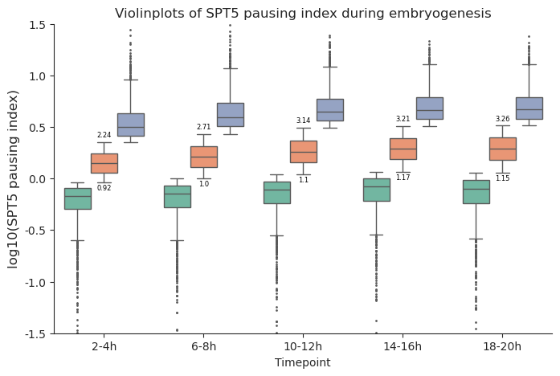

```python
import pandas as pd
import numpy as np
import seaborn as sns
import matplotlib.pyplot as plt
import re
from matplotlib.ticker import FuncFormatter

# Matplotlib parameters
plt.rcParams['font.family'] = 'Arial'
sns.set_style("ticks", {"font.family": "Arial"})
plt.rcParams.update({'pdf.fonttype': 42, 'ps.fonttype': 42})

# List of timepoints
timepoints = ["2_4h", "6_8h", "10_12h", "14_16h", "18_20h"]

# DataFrame with results
filtered_results = {}

# Load promoter index from saved .bed files for each timepoint
for timepoint in timepoints:
    bed_files = {
        f"Category_1_{timepoint}": f"/home/mayer/92_SPT4_SPT5/Manuscript/Figures/Figure_2/categories_per_timepoint/promoter_index_category_1_{timepoint}.bed",
        f"Category_2_{timepoint}": f"/home/mayer/92_SPT4_SPT5/Manuscript/Figures/Figure_2/categories_per_timepoint/promoter_index_category_2_{timepoint}.bed",
        f"Category_3_{timepoint}": f"/home/mayer/92_SPT4_SPT5/Manuscript/Figures/Figure_2/categories_per_timepoint/promoter_index_category_3_{timepoint}.bed"
    }

    for category, file_path in bed_files.items():
        bed_df = pd.read_csv(file_path, sep="\t", header=None)
        gene_names = set(bed_df[3])
        filtered_results[category] = filtered_SPT5_RNAseq[filtered_SPT5_RNAseq['gene_ID'].isin(gene_names)]


# Print how many genes are in each category and are getting plotted
for category, df in filtered_results.items():
    match = re.match(r"Category_(\d+)_(\d+)_(\d+)h", category)
    category, start, end = match.groups()
    print(f"For timepoint {start}-{end}h, category {category}: {df.shape[0]} genes were used")

# Change df to long format for seaborn
plot_data = []
for category, df in filtered_results.items():
    timepoint = "_".join(category.split('_')[-2:])
    for value in df[f"{timepoint}_promoter_index"].apply(lambda x: np.log10(x) if x > 0 else np.nan):
        plot_data.append({"Timepoint": timepoint, "log10(SPT5 pausing index)": value, "Category": category})

plot_df = pd.DataFrame(plot_data)

# Use "Set2" color palette
category_colors = {
    "Category_1": sns.color_palette("Set2")[0],
    "Category_2": sns.color_palette("Set2")[1],
    "Category_3": sns.color_palette("Set2")[2]
}

plot_df["Category"] = plot_df["Category"].apply(lambda x: "_".join(x.split("_")[:2]))


# Generate violin plot
plt.figure(figsize=(8, 5))
sns.set_style("ticks")

sns.boxplot(
    x="Timepoint",
    y="log10(SPT5 pausing index)",
    hue="Category",
    data=plot_df,
    palette=category_colors,
    width=0.8,
    dodge=True,
    fliersize=1
)


# Change ticks on x-axis
plt.xticks(ticks=range(5), labels=["2-4h", "6-8h", "10-12h", "14-16h", "18-20h"])
plt.gca().yaxis.set_major_formatter(FuncFormatter(lambda x, _: round(x, 2)))
plt.ylim(-1.5, 1.5)
sns.despine(left=False, bottom=False, right=True, top=True)

# Display min and max pausing index of category 2
for timepoint in timepoints:
    category_2_df = plot_df[plot_df['Category'] == f"Category_2"]
    min_pos = category_2_df[category_2_df['Timepoint'] == timepoint]['log10(SPT5 pausing index)'].min()
    max_pos = category_2_df[category_2_df['Timepoint'] == timepoint]['log10(SPT5 pausing index)'].max()
    min_value = 10**min_pos
    max_value = 10**max_pos
    plt.text(
        x=timepoints.index(timepoint),
        y=min_pos - 0.075,
        s=f"{round(min_value, 2)}",
        color='black',
        ha='center',
        fontsize=6
    )
    plt.text(
        x=timepoints.index(timepoint),
        y=max_pos + 0.05,
        s=f"{round(max_value, 2)}",
        color='black',
        ha='center',
        fontsize=6
    )
plt.title("Violinplots of SPT5 pausing index during embryogenesis")
plt.ylabel("log10(SPT5 pausing index)", fontsize=12)

plt.legend().remove()

plt.savefig("/home/mayer/92_SPT4_SPT5/Manuscript/Figures/Figure_2/Figure_2_B_SPT5_promoter_index_during_embryogenesis.pdf", format="pdf", transparent=True, bbox_inches='tight')
plt.show()
```

### Figure 2 C: Metaprofiles PRO-seq

```
plot saved at /home/mayer/92_SPT4_SPT5/Manuscript/Figures/Figure_2/Figure_2_C_metaprofile_PROseq_3_4h.pdf
highest bin 115 for bottom 25% with value: 0.11
second highest bin 116 for bottom 25% with value: 0.11
highest bin 72 for middle 50% with value: 0.20
second highest bin 76 for middle 50% with value: 0.20
highest bin 55 for top 25% with value: 0.62
second highest bin 54 for top 25% with value: 0.62
```

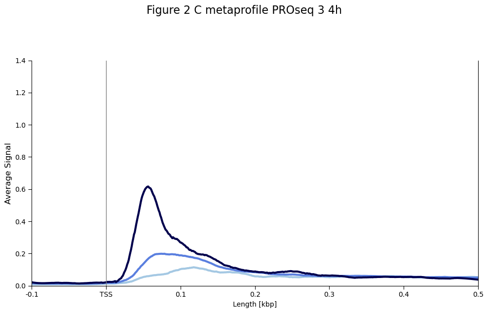

```
plot saved at /home/mayer/92_SPT4_SPT5/Manuscript/Figures/Figure_2/Figure_2_C_metaprofile_PROseq_18_20h.pdf
highest bin 62 for bottom 25% with value: 0.12
second highest bin 60 for bottom 25% with value: 0.12
highest bin 55 for middle 50% with value: 0.44
second highest bin 56 for middle 50% with value: 0.44
highest bin 53 for top 25% with value: 1.32
second highest bin 52 for top 25% with value: 1.32
```

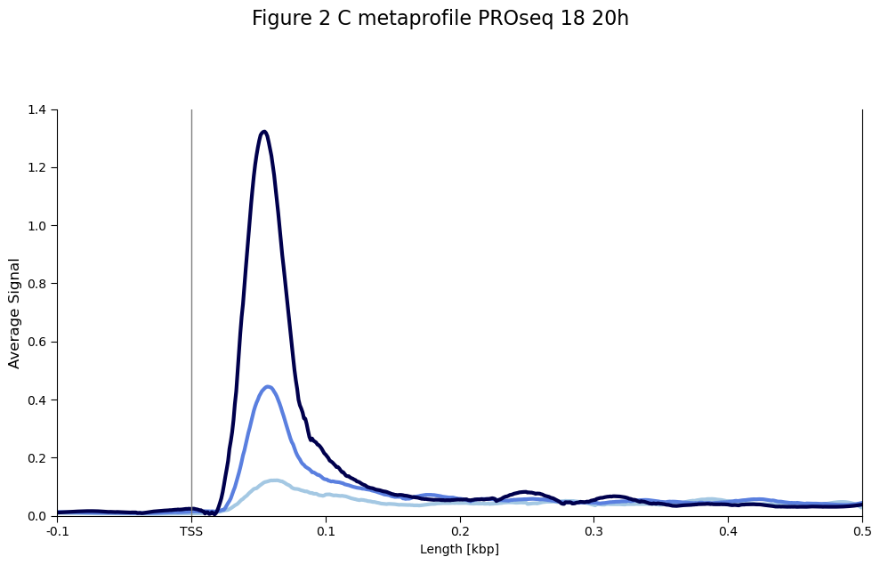

```python
import pandas as pd
import gzip
import json
import matplotlib.pyplot as plt
import matplotlib.cm as cm
import matplotlib as mpl
mpl.rcParams['pdf.fonttype'] = 42
mpl.rcParams['ps.fonttype'] = 42
plt.rcParams['font.family'] = 'sans-serif'
plt.rcParams['font.sans-serif'] = ['DejaVu Sans']


def load_matrix_data(matrix_path):
    """Load matrix data and header information from the gzipped file."""
    with gzip.open(matrix_path, 'rt') as f:
        header = f.readline()  # First line is the header

    header_data = json.loads(header.strip('@'))  # Remove '@' and parse JSON

    # Extract sample labels and boundaries
    sample_labels = header_data["sample_labels"]
    sample_boundaries = header_data["sample_boundaries"]
    group_boundaries = header_data["group_boundaries"]

    # Load the actual matrix data
    matrix_df = pd.read_csv(matrix_path, sep='\t', compression='gzip', skiprows=1, header=None)

    return matrix_df, sample_labels, sample_boundaries, group_boundaries


def split_clusters(matrix_df, group_boundaries, start_timepoint, end_timepoint):

    """Split the matrix based on group boundaries and calculate averages."""
    # Extract rows corresponding to different groups and compute averages
    cluster_1 = matrix_df.iloc[group_boundaries[0]:group_boundaries[1], start_timepoint:end_timepoint]
    cluster_2 = matrix_df.iloc[group_boundaries[1]:group_boundaries[2], start_timepoint:end_timepoint]
    cluster_3 = matrix_df.iloc[group_boundaries[2]:group_boundaries[3], start_timepoint:end_timepoint]

    cluster_1_avg = cluster_1.apply(pd.to_numeric, errors='coerce').iloc[:, 6:].mean(axis=0)
    cluster_2_avg = cluster_2.apply(pd.to_numeric, errors='coerce').iloc[:, 6:].mean(axis=0)
    cluster_3_avg = cluster_3.apply(pd.to_numeric, errors='coerce').iloc[:, 6:].mean(axis=0)

    return cluster_1_avg, cluster_2_avg, cluster_3_avg


def plot_cluster_data(clusters_timepoint_all, output_path, center, maximum, minimum=0):
    """Plot data for each cluster over timepoints with a viridis color palette."""
    fig, ax = plt.subplots(1, 1, figsize=(10, 6))
    colors_list = ["#a4c8e3", "#5a7fdf", "#00004d"]

    title = output_path.split('/')[-1].replace('.pdf', '').replace('_', ' ')

    for category, timepoint in enumerate(clusters_timepoint_all):
        for i, cluster in enumerate(timepoint):
            if cluster:
                ax.plot(range(len(cluster[0])), cluster[0], label=f'Cluster {i+1}', color=colors_list[category], linewidth=3)  # Cluster plotten

    # Customize the plot with axis labels and grid lines
    ax.set_ylabel('Average Signal', fontsize=12)
    ax.set_xlabel('Length [kbp]')
    ax.set_xlim(0, 594)
    ax.set_facecolor('white')
    ax.spines['top'].set_visible(False)
    ax.tick_params(axis='x', length=5)
    ax.tick_params(axis='y', length=5)

    if center == "TSS":
        ax.axvline(x=99, color='grey', linestyle='-', linewidth=1)
        ax.set_xticks([0, 99, 198, 297, 396, 495, 594])
        ax.set_xticklabels(['-0.1', 'TSS', '0.1', '0.2', '0.3', '0.4', '0.5'], fontsize=10)
        ax.set_ylim(minimum, maximum)

    plt.suptitle(title, fontsize=16, y=1.05)
    plt.tight_layout(rect=[0, 0, 1, 0.96])
    plt.savefig(output_path)
    plt.show()
    plt.close()

from scipy.signal import savgol_filter
def smooth_signal(signal, window_size=51, poly_order=3):
        """Apply Savitzky-Golay filter for smoothing."""
        return savgol_filter(signal, window_size, poly_order)

def plot_matrix(matrix_path, output_path, center, maximum, minimum=False):
    """Main function to load data, process it, and plot metaprofiles for each cluster."""
    # Load data from the gzipped matrix
    matrix_df, sample_labels, sample_boundaries, group_boundaries = load_matrix_data(matrix_path)

    cluster_all_timepoints = [
    [[]], [[]], [[]]
    ]

    for index in range(1):
        start_timepoint = sample_boundaries[index]
        end_timepoint = sample_boundaries[index+1]
        cluster_1, cluster_2, cluster_3 = split_clusters(matrix_df, group_boundaries, start_timepoint, end_timepoint)

        cluster_1_smoothed = smooth_signal(cluster_1)
        cluster_2_smoothed = smooth_signal(cluster_2)
        cluster_3_smoothed = smooth_signal(cluster_3)


        cluster_all_timepoints[0][index].append(cluster_1_smoothed)
        cluster_all_timepoints[1][index].append(cluster_2_smoothed)
        cluster_all_timepoints[2][index].append(cluster_3_smoothed)

        top_2_indices = cluster_1_smoothed.argsort()[-2:][::-1]  # Top 2 Indizes
        top_2_values = cluster_1_smoothed[top_2_indices]
        print(f"highest bin {top_2_indices[0]-100} for bottom 25% with value: {top_2_values[0]:.2f}")
        print(f"second highest bin {top_2_indices[1]-100} for bottom 25% with value: {top_2_values[1]:.2f}")

        top_2_indices = cluster_2_smoothed.argsort()[-2:][::-1]  # Top 2 Indizes
        top_2_values = cluster_2_smoothed[top_2_indices]
        print(f"highest bin {top_2_indices[0]-100} for middle 50% with value: {top_2_values[0]:.2f}")
        print(f"second highest bin {top_2_indices[1]-100} for middle 50% with value: {top_2_values[1]:.2f}")

        top_2_indices = cluster_3_smoothed.argsort()[-2:][::-1]  # Top 2 Indizes
        top_2_values = cluster_3_smoothed[top_2_indices]
        print(f"highest bin {top_2_indices[0]-100} for top 25% with value: {top_2_values[0]:.2f}")
        print(f"second highest bin {top_2_indices[1]-100} for top 25% with value: {top_2_values[1]:.2f}")


    plot_cluster_data(cluster_all_timepoints, output_path, center, maximum, minimum)

directory = "/g/furlong/project/92_SPT4_SPT5/PROseq/analysis/deeptools_1bpBins/adapted/"
plot_dir  = "/home/mayer/92_SPT4_SPT5/Manuscript/Figures/Figure_2/"

# Plotting of PROseq
matrix_path = directory + "PROseq_test2_34h_TSS_1bpBins_TSS_NaN.gz"
output_path = plot_dir +  "Figure_2_C_metaprofile_PROseq_3_4h.pdf"
print(f"plot saved at {output_path}")
plot_matrix(matrix_path, output_path, center="TSS", maximum=1.4)

matrix_path = directory + "PROseq_test3_1820h_TSS_1bpBins_TSS_NaN.gz"
output_path = plot_dir +  "Figure_2_C_metaprofile_PROseq_18_20h.pdf"
print(f"plot saved at {output_path}")
plot_matrix(matrix_path, output_path, center="TSS", maximum=1.4)
```

### Figure 2 D: Violinplots RNAseq gene expression per category

[output not shown]

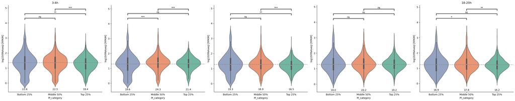

```python
import pandas as pd
import numpy as np
import seaborn as sns
import matplotlib.pyplot as plt
from scipy.stats import mannwhitneyu

# Lade NELF-Daten
NELF_df = pd.read_csv("/home/mayer/92_SPT4_SPT5/Depletion_CUTnTag/data/tables/NELF_binding_merged.csv")

# Lade FPKM-Daten
file_path = "/g/furlong/project/85_seqFISH/data/gene_expression/gene_expression_across_embryogenesis_FPKM.txt"
FPKMs = pd.read_csv(file_path, sep='\t')
fpkm_columns = [
    "gene_ID",
    "gene_name",
    "2-4h",
    "6-8h",
    "10-12h",
    "14-16h",
    "18-20h"
]
fpkm_df = FPKMs[fpkm_columns]

# Kombiniere NELF und Expressionsdaten
merged_NELF_peaks_expression = pd.merge(NELF_df, fpkm_df, on='gene_ID')

# Definiere eine Funktion, die die Kategorien für einen bestimmten Zeitpunkt zuweist
def load_categories_for_timepoint(timepoint):
    if timepoint == "2-4h":
        category_1 = pd.read_csv("/home/mayer/92_SPT4_SPT5/Manuscript/Figures/Figure_2/categories_per_timepoint/promoter_index_category_1_2_4h.bed", sep='\t', header=None)
        category_2 = pd.read_csv("/home/mayer/92_SPT4_SPT5/Manuscript/Figures/Figure_2/categories_per_timepoint/promoter_index_category_2_2_4h.bed", sep='\t', header=None)
        category_3 = pd.read_csv("/home/mayer/92_SPT4_SPT5/Manuscript/Figures/Figure_2/categories_per_timepoint/promoter_index_category_3_2_4h.bed", sep='\t', header=None)
    elif timepoint == "6-8h":
        category_1 = pd.read_csv("/home/mayer/92_SPT4_SPT5/Manuscript/Figures/Figure_2/categories_per_timepoint/promoter_index_category_1_6_8h.bed", sep='\t', header=None)
        category_2 = pd.read_csv("/home/mayer/92_SPT4_SPT5/Manuscript/Figures/Figure_2/categories_per_timepoint/promoter_index_category_2_6_8h.bed", sep='\t', header=None)
        category_3 = pd.read_csv("/home/mayer/92_SPT4_SPT5/Manuscript/Figures/Figure_2/categories_per_timepoint/promoter_index_category_3_6_8h.bed", sep='\t', header=None)
    elif timepoint == "10-12h":
        category_1 = pd.read_csv("/home/mayer/92_SPT4_SPT5/Manuscript/Figures/Figure_2/categories_per_timepoint/promoter_index_category_1_10_12h.bed", sep='\t', header=None)
        category_2 = pd.read_csv("/home/mayer/92_SPT4_SPT5/Manuscript/Figures/Figure_2/categories_per_timepoint/promoter_index_category_2_10_12h.bed", sep='\t', header=None)
        category_3 = pd.read_csv("/home/mayer/92_SPT4_SPT5/Manuscript/Figures/Figure_2/categories_per_timepoint/promoter_index_category_3_10_12h.bed", sep='\t', header=None)
    elif timepoint == "14-16h":
        category_1 = pd.read_csv("/home/mayer/92_SPT4_SPT5/Manuscript/Figures/Figure_2/categories_per_timepoint/promoter_index_category_1_14_16h.bed", sep='\t', header=None)
        category_2 = pd.read_csv("/home/mayer/92_SPT4_SPT5/Manuscript/Figures/Figure_2/categories_per_timepoint/promoter_index_category_2_14_16h.bed", sep='\t', header=None)
        category_3 = pd.read_csv("/home/mayer/92_SPT4_SPT5/Manuscript/Figures/Figure_2/categories_per_timepoint/promoter_index_category_3_14_16h.bed", sep='\t', header=None)
    elif timepoint == "18-20h":
        category_1 = pd.read_csv("/home/mayer/92_SPT4_SPT5/Manuscript/Figures/Figure_2/categories_per_timepoint/promoter_index_category_1_18_20h.bed", sep='\t', header=None)
        category_2 = pd.read_csv("/home/mayer/92_SPT4_SPT5/Manuscript/Figures/Figure_2/categories_per_timepoint/promoter_index_category_2_18_20h.bed", sep='\t', header=None)
        category_3 = pd.read_csv("/home/mayer/92_SPT4_SPT5/Manuscript/Figures/Figure_2/categories_per_timepoint/promoter_index_category_3_18_20h.bed", sep='\t', header=None)

    # Extrahiere Gene IDs
    category_1_genes = set(category_1[3])
    category_2_genes = set(category_2[3])
    category_3_genes = set(category_3[3])

    def assign_category(gene_id):
        if gene_id in category_1_genes:
            return 1
        elif gene_id in category_2_genes:
            return 2
        elif gene_id in category_3_genes:
            return 3
        return None

    return assign_category

# Generiere Subplots
timepoints = ["2-4h", "6-8h", "10-12h", "14-16h", "18-20h"]
expression_column = {"2-4h": "2-4h", "6-8h": "6-8h", "10-12h": "10-12h", "14-16h": "14-16h", "18-20h": "18-20h"}

fig, axes = plt.subplots(1, 5, figsize=(30, 6))

# Erstelle die Plots
for i, timepoint in enumerate(timepoints):
    assign_category = load_categories_for_timepoint(timepoint)

    # Expression Daten für den jeweiligen Zeitpunkt
    expression_data = merged_NELF_peaks_expression[[expression_column[timepoint], "gene_ID"]].dropna()
    expression_data["log_expr"] = np.log10(expression_data[expression_column[timepoint]] + 1)
    expression_data["PI_category"] = expression_data["gene_ID"].apply(assign_category)
    expression_data.dropna(subset=["PI_category"], inplace=True)
    expression_data["PI_category"] = expression_data["PI_category"].map({1: 'Bottom 25%', 2: 'Middle 50%', 3: 'Top 25%'})
    y_min = expression_data[expression_column[timepoint]].min() - 0.5

    # Violinplot für Expression
    ax = axes[i]
    sns.violinplot(x="PI_category", y="log_expr", data=expression_data, ax=ax,
                   palette={'Top 25%': '#66c2a5', 'Middle 50%': '#fc8d62', 'Bottom 25%': '#8da0cb'})
    #ax = plt.gca()  # Aktuelle Achse holen
    ax.spines['right'].set_visible(False)
    ax.spines['top'].set_visible(False)
        # Ändere Titel und Y-Achsenlabel
    if timepoint == "2-4h":
        ax.set_title("3-4h")  # Titel für den linken Plot
    elif timepoint == "18-20h":
        ax.set_title("18-20h")  # Titel für den rechten Plot
    ax.set_ylabel("log10(RNAseq) [RPKM]")  # Y-Achse Label ändern

    # Berechne und zeige Median für jede Kategorie
    for category in ['Bottom 25%', 'Middle 50%', 'Top 25%']:
        median_value = expression_data[expression_data["PI_category"] == category]["log_expr"].median()
        ax.text(x=['Bottom 25%', 'Middle 50%', 'Top 25%'].index(category), y=y_min,
                s=f"{10**median_value:.1f}", ha='center', va='bottom', fontsize=10, color='black')


    # Horizontale gestrichelte Linie für den Median der Kategorie "Top 25%" (Kategorie 1)
    category_1_median = expression_data[expression_data["PI_category"] == 'Bottom 25%']["log_expr"].median()
    ax.axhline(y=category_1_median, color='grey', linestyle='--', label="Median Top 25%", alpha=0.8)
    # Rechte und obere Plotbegrenzung ausblenden


    # Mann-Whitney U-Test zwischen den Kategorien
    y_max_expr = expression_data['log_expr'].max() + 0.5
    y_start_expr = y_max_expr + 0.1
    categories = ['Bottom 25%', 'Middle 50%', 'Top 25%']

    for cat1, cat2 in [('Bottom 25%', 'Middle 50%'), ('Bottom 25%', 'Top 25%'), ('Middle 50%', 'Top 25%')]:
        data1 = expression_data[expression_data["PI_category"] == cat1]["log_expr"]
        data2 = expression_data[expression_data["PI_category"] == cat2]["log_expr"]
        if len(data1) > 0 and len(data2) > 0:
            _, p_value = mannwhitneyu(data1, data2, alternative='two-sided')

            if p_value < 0.001:
                significance = '***'
            elif p_value < 0.01:
                significance = '**'
            elif p_value < 0.05:
                significance = '*'
            else:
                significance = 'ns'

            x1_pos, x2_pos = categories.index(cat1), categories.index(cat2)

            ax.plot([x1_pos, x1_pos, x2_pos, x2_pos], [y_start_expr, y_start_expr + 0.1, y_start_expr + 0.1, y_start_expr], color='black')
            ax.text((x1_pos + x2_pos) / 2, y_start_expr + 0.1, significance, ha='center', va='bottom', color='black')
            y_start_expr += 0.3

# Passe Layout an


plt.tight_layout()
plt.savefig("/home/mayer/92_SPT4_SPT5/Manuscript/Figures/Figure_2/violin_plots/Figure_2_D_violin_expression.pdf")
plt.show()
```

### Figure 2E: SPT5 PI z-score violin plots

Determine clusters from Fig1C

```python
import pandas as pd
import os
import plotly.graph_objects as go
from sklearn.cluster import KMeans
import numpy as np
from scipy.stats import zscore
from plotly.subplots import make_subplots

# Load SPT5 data
input_file = "/g/furlong/project/92_SPT4_SPT5/CUTnTag/data/tables/SPT5_binding_merged.csv"
SPT5_all_df = pd.read_csv(input_file)
mean_RPKM_columns = [
    "gene_ID",
    "2_4h_mean_rpkm",
    "6_8h_mean_rpkm",
    "10_12h_mean_rpkm",
    "14_16h_mean_rpkm",
    "18_20h_mean_rpkm"
]
SPT5_df = SPT5_all_df[mean_RPKM_columns]

# Load RNAseq data and rename columns
file_path = "/g/furlong/project/85_seqFISH/data/gene_expression/gene_expression_across_embryogenesis_FPKM.txt"
RNAseq_all_df = pd.read_csv(file_path, sep='\t')
RNAseq_columns = [
    "gene_ID",
    "2-4h",
    "6-8h",
    "10-12h",
    "14-16h",
    "18-20h"
]
RNAseq_df = RNAseq_all_df[RNAseq_columns]

# Merge both DataFrames based on 'gene_ID'
SPT5_RNAseq_df = pd.merge(SPT5_df, RNAseq_df, on='gene_ID')

# Drop rows with missing values
SPT5_RNAseq_df_valid = SPT5_RNAseq_df.dropna().copy()

# Normalize RPKM and FPKM columns using z-score
SPT5_RNAseq_df_valid.iloc[:, 1:6] = SPT5_RNAseq_df_valid.iloc[:, 1:6].apply(zscore, axis=1).copy()  # Normalize RPKM columns
SPT5_RNAseq_df_valid.iloc[:, 6:11] = SPT5_RNAseq_df_valid.iloc[:, 6:11].apply(zscore, axis=1).copy()  # Normalize FPKM columns

SPT5_RNAseq_df_valid = SPT5_RNAseq_df_valid.dropna(subset=SPT5_RNAseq_df_valid.columns[1:11])

# KMeans clustering with 3 clusters
n_clusters = 3
kmeans = KMeans(n_clusters=n_clusters, random_state=42)
SPT5_RNAseq_df_valid['cluster'] = kmeans.fit_predict(SPT5_RNAseq_df_valid.iloc[:, 1:11]).copy()  # Use RPKM and FPKM columns for clustering

# Change order so first cluster is decreasing, second is transient and third cluster is increasing
custom_order = {0: 2, 1: 0, 2: 1}
SPT5_RNAseq_df_valid['cluster'] = SPT5_RNAseq_df_valid['cluster'].map(custom_order)
sorted_SPT5_RNAseq_df_valid = SPT5_RNAseq_df_valid.sort_values(by=['cluster'])
print(f"using {len(sorted_SPT5_RNAseq_df_valid)} genes for plotting")

# Merge the clustering result with bed_df to get full gene information
merged_cluster_df = pd.merge(SPT5_all_df, sorted_SPT5_RNAseq_df_valid[['gene_ID', 'cluster']], on='gene_ID')
merged_values_df = pd.merge(merged_cluster_df, RNAseq_all_df[['gene_ID', "2-4h", "6-8h", "10-12h", "14-16h", "18-20h"]], on='gene_ID')
```

```
using 13168 genes for plotting
```

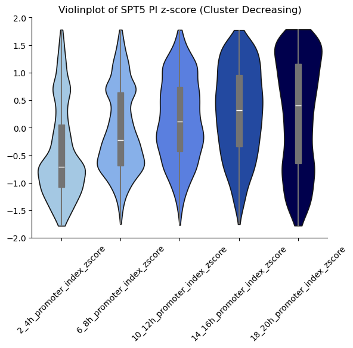

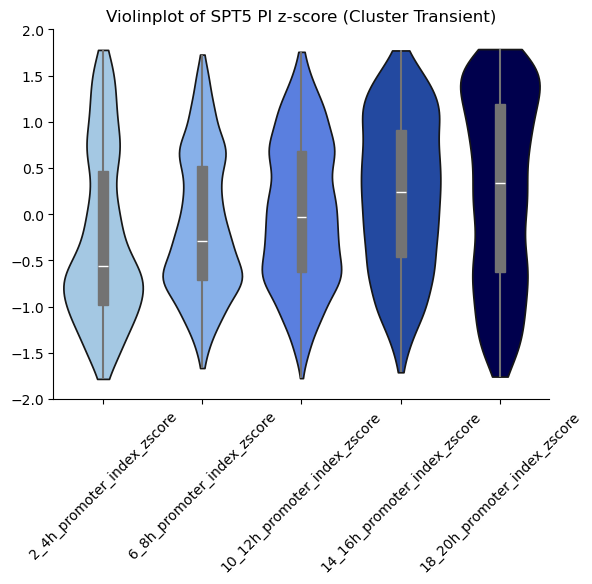

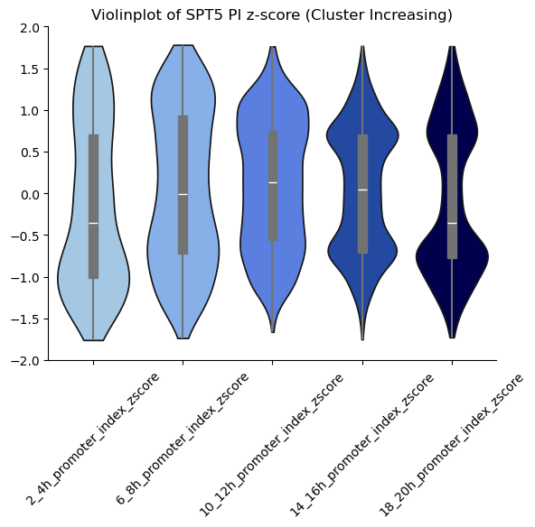

```python
import pandas as pd
import seaborn as sns
import matplotlib.pyplot as plt
import numpy as np
from scipy.stats import zscore

violin_plot_merged = merged_values_df.copy()

promoter_index_cols = ["2_4h_promoter_index", "6_8h_promoter_index", "10_12h_promoter_index",
                       "14_16h_promoter_index", "18_20h_promoter_index"]

# calculate z-score
def compute_zscore(df, col_list):
    return df[col_list].sub(df[col_list].mean(axis=1), axis=0).div(df[col_list].std(axis=1), axis=0)

violin_plot_merged[[col + "_zscore" for col in promoter_index_cols]] = compute_zscore(violin_plot_merged, promoter_index_cols)

categories = {
    "SPT5 PI z-score": [col + "_zscore" for col in promoter_index_cols],
}

cluster_naming = {
    0: "Decreasing",
    1: "Transient",
    2: "Increasing"
}
# Draw Violinplots + Boxplot
for category, value_columns in categories.items():
    for cluster in sorted(violin_plot_merged['cluster'].unique()):
        colors_list = ["#a4c8e3", "#87b0e9", "#5a7fdf", "#2349a0", "#00004d"]

        # get values from cluster
        cluster_df = violin_plot_merged[violin_plot_merged['cluster'] == cluster]

        data_list = []
        time_labels = []
        color_labels = []
        for index, col in enumerate(value_columns):
            timepoint_values = cluster_df[col].dropna()  # ignore NA-values
            if not timepoint_values.empty:
                data_list.append(timepoint_values)
                time_labels.append(col)
                color_labels.append(colors_list[index])

        # Add Violinplot
        sns.violinplot(data=data_list, cut=0, palette=color_labels, saturation=1, inner=None, dodge=False)

        # Add Boxplot
        sns.boxplot(
            data=data_list,
            showcaps=False,  #
            showfliers=False,
            whiskerprops={'color': '#737373', 'linewidth':1.5},
            boxprops={'facecolor':'#737373' , 'edgecolor': '#737373'},
            medianprops={'color': 'white'},
            width=0.1,
            dodge=False
        )


        plt.xticks(ticks=range(len(time_labels)), labels=time_labels, rotation=45)
        plt.title(f'Violinplot of {category} (Cluster {cluster_naming[cluster]})')
        plt.ylim(-2, 2)


        filename = f"/home/mayer/92_SPT4_SPT5/Manuscript/Figures/Figure_2/violin_plots/violinplot_{category}_Cluster{cluster}.pdf"
        ax = plt.gca()  # Aktuelle Achse holen
        ax.spines['right'].set_visible(False)
        ax.spines['top'].set_visible(False)
        plt.show()
        plt.savefig(filename)
```

### Figure 2 F: Metaprofiles Depletion CUT&Tag NELF, Pol2pSer2, Pol2pSer5

[figure not shown]

```python
import pandas as pd
import matplotlib.pyplot as plt
import gzip
import json

def load_matrix_data(matrix_path):
    """Load matrix data and header information from the gzipped file."""
    with gzip.open(matrix_path, 'rt') as f:
        header = f.readline()

    header_data = json.loads(header.strip('@'))

    sample_labels = header_data["sample_labels"]
    sample_boundaries = header_data["sample_boundaries"]
    group_boundaries = header_data["group_boundaries"]

    matrix_df = pd.read_csv(matrix_path, sep='\t', compression='gzip', skiprows=1, header=None)

    return matrix_df, sample_labels, sample_boundaries, group_boundaries


def split_clusters(matrix_df, group_boundaries, start_timepoint, end_timepoint):
    """Split the matrix based on group boundaries and calculate averages."""
    cluster_1 = matrix_df.iloc[group_boundaries[0]:group_boundaries[1], start_timepoint:end_timepoint]
    cluster_2 = matrix_df.iloc[group_boundaries[1]:group_boundaries[2], start_timepoint:end_timepoint]
    cluster_3 = matrix_df.iloc[group_boundaries[2]:group_boundaries[3], start_timepoint:end_timepoint]

    cluster_1_avg = cluster_1.apply(pd.to_numeric, errors='coerce').iloc[:, 6:].mean(axis=0)
    cluster_2_avg = cluster_2.apply(pd.to_numeric, errors='coerce').iloc[:, 6:].mean(axis=0)
    cluster_3_avg = cluster_3.apply(pd.to_numeric, errors='coerce').iloc[:, 6:].mean(axis=0)

    return cluster_1_avg, cluster_2_avg, cluster_3_avg


def plot_cluster_data(clusters_timepoint_all, ax_col, center):
    """Plot data for each cluster over timepoints."""
    colors_list = ["#a4c8e3", "#5a7fdf", "#00004d"]

    for category, timepoint in enumerate(clusters_timepoint_all):
        for i, cluster in enumerate(timepoint):
            ax_col[i].plot(range(len(cluster[0])), cluster[0], label=f'Cluster {i+1}', color=colors_list[category], linewidth=2)

    for i in range(3):  #
        ax_col[i].set_ylabel('Average Signal', fontsize=12)
        ax_col[i].set_xlim(0, 100)
        ax_col[i].set_facecolor('white')
        ax_col[i].spines['top'].set_visible(False)
        ax_col[i].tick_params(axis='x', length=5)
        ax_col[i].tick_params(axis='y', length=5)

        if center == "TSS":
            ax_col[i].axvline(x=100, color='grey', linestyle='-', linewidth=1)
            ax_col[i].set_xticks([0, 100, 595])
            ax_col[i].set_xticklabels(['-1kbp', 'TSS', '+5kbp'], fontsize=10)


def plot_matrix(matrix_path, axes, center):
    """Load data, process it, and plot for each cluster."""
    matrix_df, sample_labels, sample_boundaries, group_boundaries = load_matrix_data(matrix_path)

    cluster_all_timepoints = [[[], [], []] for _ in range(3)]  # 3 pausing clusters

    for index in range(3):  # 2 timepoints 2-4h and 18-20h
        start_timepoint = sample_boundaries[index]
        end_timepoint = sample_boundaries[index+1]
        cluster_1, cluster_2, cluster_3 = split_clusters(matrix_df, group_boundaries, start_timepoint, end_timepoint)
        cluster_all_timepoints[0][index].append(cluster_1)
        cluster_all_timepoints[1][index].append(cluster_2)
        cluster_all_timepoints[2][index].append(cluster_3)

    plot_cluster_data(cluster_all_timepoints, axes, center)



plot_dir = "/home/mayer/92_SPT4_SPT5/Manuscript/Figures/Figure_2/heatmaps/"
matrix_files = [
    "adapted/Figure_S_2_X_BL34_3h_Dark_NELF_pSer2_pSer5_pausing_index_categories_NaN.gz",
    "adapted/Figure_S_2_X_BL1012_2h_Dark_NELF_pSer2_pSer5_pausing_index_categories_NaN.gz",
    "adapted/Figure_S_2_X_BL1820_2h_Dark_NELF_pSer2_pSer5_pausing_index_categories_NaN.gz"
]


# Create the figure and axes
fig, axes = plt.subplots(3, 3, figsize=(10, 10))

antibodies = ['NELF', 'pSer2', 'pSer5']
timepoints = ['2-4h', '10-12h', '18-20h']
max_values = [80, 85, 125]  # maximum value for y-scale in plot per antibody

# plot antibodies
for col, matrix_file in enumerate(matrix_files):
    matrix_path = plot_dir + matrix_file
    plot_matrix(matrix_path, axes[:3, col], "TSS")

# Set titles for rows (Antibodies) and columns (Timepoints)
for i, ax_row in enumerate(axes):
    for j, ax in enumerate(ax_row):
        ax.set_title(f'{antibodies[i]} - {timepoints[j]}', fontsize=12)
        ax.set_ylim(0, max_values[i])


plt.tight_layout()
output_path = plot_dir + "plots/Figure_2_F_NELF_pSer2_pSer5.pdf"
plt.savefig(output_path)
plt.show()
plt.close()
```

### Figure 2 G: upset plot NELF binding

```python
import pandas as pd

# CSV-Datei als DataFrame einlesen
NELF_df = pd.read_csv('/home/mayer/92_SPT4_SPT5/Manuscript/Figures/Figure_2/NELF_df.csv')

# Relevante Spalten extrahieren
NELF_df_selected = NELF_df[["gene_ID", "34h_3h_peak", "1012h_2h_peak", "1820h_2h_peak"]]

# DataFrame mit filtered_SPT5_NELF_RNAseq anhand gene_ID mergen
filtered_SPT5_NELF_RNAseq = NELF_df_selected.merge(filtered_SPT5_RNAseq, on="gene_ID", how="inner")
```

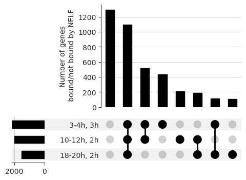

```python
import pandas as pd
import matplotlib.pyplot as plt
from upsetplot import UpSet
from matplotlib.ticker import FuncFormatter
import warnings
warnings.simplefilter(action='ignore', category=FutureWarning)


# Matplotlib parameters
plt.rcParams['font.family'] = 'DejaVu Sans'
sns.set_style("ticks", {"font.family": 'DejaVu Sans'})
plt.rcParams.update({'pdf.fonttype': 42, 'ps.fonttype': 42})

SPT5_bound_genes = filtered_SPT5_NELF_RNAseq.copy()
# Filter genes that are bound by SPT5
SPT5_bound_genes = SPT5_bound_genes.dropna(subset=["2_4h_promoter_index", "10_12h_promoter_index", "18_20h_promoter_index"])

# Create a new column for NELF binding at the same timepoints
NELF_columns = ["34h_3h_peak", "1012h_2h_peak", "1820h_2h_peak"]
SPT5_bound_genes.loc[:, "NELF_bound"] = SPT5_bound_genes[NELF_columns].apply(lambda row: tuple(row), axis=1)

NELF_column_mapping = {
    "34h_3h_peak": "3-4h, 3h",
    "1012h_2h_peak": "10-12h, 2h",
    "1820h_2h_peak": "18-20h, 2h"
}


SPT5_bound_genes = SPT5_bound_genes.rename(columns=NELF_column_mapping)


# Generate upset dataframe
upset_data = SPT5_bound_genes["NELF_bound"].value_counts()

upset_data.index = pd.MultiIndex.from_tuples(upset_data.index, names=["3-4h, 3h", "10-12h, 2h", "18-20h, 2h"])
upset_data_sorted = upset_data.sort_values(ascending=False)

# Plot upset plot
upset = UpSet(upset_data_sorted, sort_by="cardinality", sort_categories_by="-cardinality")

# Plot anzeigen
upset.plot()
plt.xlabel("Timepoint")
plt.ylabel("Number of genes\n bound/not bound by NELF")

plt.savefig("/home/mayer/92_SPT4_SPT5/Manuscript/Figures/Figure_2/Figure_2_G_NELF_bound_genes_upset_plot.pdf")
plt.show()
```

### Supplementary Figure 2 A: metaprofiles SPT5 for three PI categories across embryogenesis

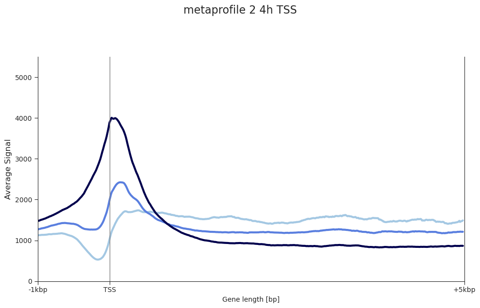

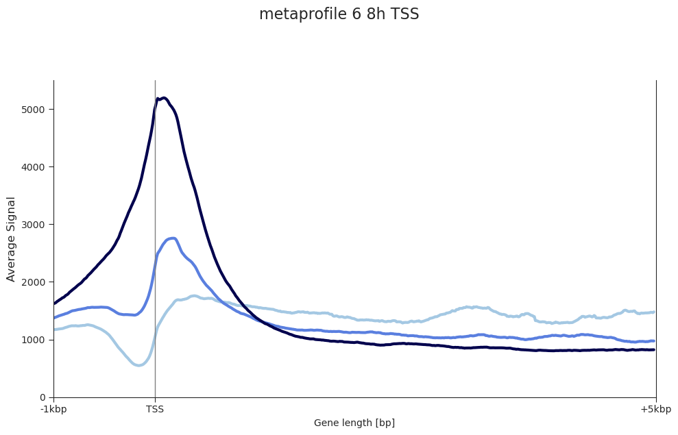

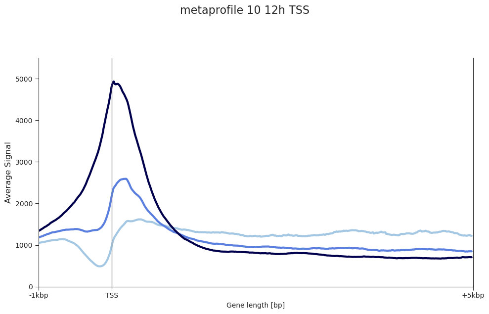

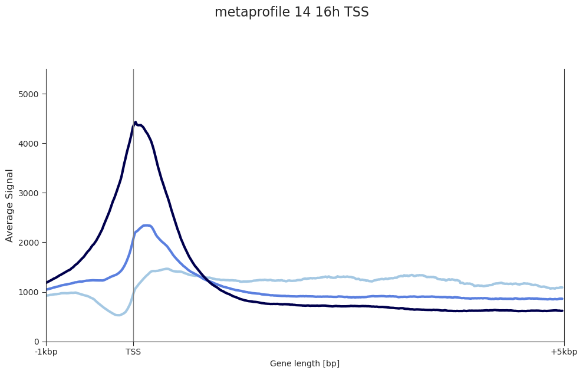

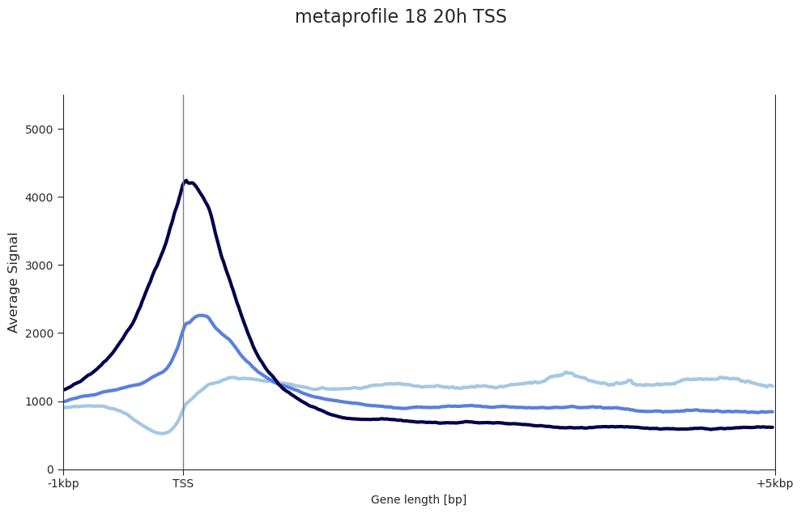

```python
import pandas as pd
import gzip
import json
import matplotlib.pyplot as plt
import matplotlib.cm as cm
import matplotlib as mpl
mpl.rcParams['pdf.fonttype'] = 42
mpl.rcParams['ps.fonttype'] = 42
plt.rcParams['font.family'] = 'sans-serif'
plt.rcParams['font.sans-serif'] = ['DejaVu Sans']


def load_matrix_data(matrix_path):
    """Load matrix data and header information from the gzipped file."""
    with gzip.open(matrix_path, 'rt') as f:
        header = f.readline()  # First line is the header

    header_data = json.loads(header.strip('@'))  # Remove '@' and parse JSON

    # Extract sample labels and boundaries
    sample_labels = header_data["sample_labels"]
    sample_boundaries = header_data["sample_boundaries"]
    group_boundaries = header_data["group_boundaries"]

    # Load the actual matrix data
    matrix_df = pd.read_csv(matrix_path, sep='\t', compression='gzip', skiprows=1, header=None)

    return matrix_df, sample_labels, sample_boundaries, group_boundaries


def split_clusters(matrix_df, group_boundaries, start_timepoint, end_timepoint):

    """Split the matrix based on group boundaries and calculate averages."""
    # Extract rows corresponding to different groups and compute averages
    cluster_1 = matrix_df.iloc[group_boundaries[0]:group_boundaries[1], start_timepoint:end_timepoint]
    cluster_2 = matrix_df.iloc[group_boundaries[1]:group_boundaries[2], start_timepoint:end_timepoint]
    cluster_3 = matrix_df.iloc[group_boundaries[2]:group_boundaries[3], start_timepoint:end_timepoint]

    cluster_1_avg = cluster_1.apply(pd.to_numeric, errors='coerce').iloc[:, 6:].mean(axis=0)
    cluster_2_avg = cluster_2.apply(pd.to_numeric, errors='coerce').iloc[:, 6:].mean(axis=0)
    cluster_3_avg = cluster_3.apply(pd.to_numeric, errors='coerce').iloc[:, 6:].mean(axis=0)

    return cluster_1_avg, cluster_2_avg, cluster_3_avg


def plot_cluster_data(clusters_timepoint_all, output_path, center, maximum, minimum=0):
    """Plot data for each cluster over timepoints with a viridis color palette."""
    fig, ax = plt.subplots(1, 1, figsize=(10, 6))
    colors_list = ["#a4c8e3", "#5a7fdf", "#00004d"]

    title = output_path.split('/')[-1].replace('.pdf', '').replace('_', ' ')

    for category, timepoint in enumerate(clusters_timepoint_all):
        for i, cluster in enumerate(timepoint):
            if cluster:
                ax.plot(range(len(cluster[0])), cluster[0], label=f'Cluster {i+1}', color=colors_list[category], linewidth=3)  # Cluster plotten

    # Customize the plot with axis labels and grid lines
    ax.set_ylabel('Average Signal', fontsize=12)
    ax.set_xlabel('Gene length [bp]')
    ax.set_xlim(0, 595)
    ax.set_facecolor('white')
    ax.spines['top'].set_visible(False)
    ax.tick_params(axis='x', length=5)
    ax.tick_params(axis='y', length=5)

    if center == "TSS":
        ax.axvline(x=100, color='grey', linestyle='-', linewidth=1)
        ax.set_xticks([0, 100, 595])
        ax.set_xticklabels(['-1kbp', 'TSS', '+5kbp'], fontsize=10)
        ax.set_ylim(minimum, maximum)

    plt.suptitle(title, fontsize=16, y=1.05)
    plt.tight_layout(rect=[0, 0, 1, 0.96])
    plt.savefig(output_path)
    plt.show()
    plt.close()


def plot_matrix(matrix_path, output_path, center, maximum, minimum=False):
    """Main function to load data, process it, and plot metaprofiles for each cluster."""
    # Load data from the gzipped matrix
    matrix_df, sample_labels, sample_boundaries, group_boundaries = load_matrix_data(matrix_path)

    cluster_all_timepoints = [
    [[], [], [], [], []],
    [[], [], [], [], []],
    [[], [], [], [], []]
    ]

    for index in range(1):
        start_timepoint = sample_boundaries[index]
        end_timepoint = sample_boundaries[index+1]
        cluster_1, cluster_2, cluster_3 = split_clusters(matrix_df, group_boundaries, start_timepoint, end_timepoint)
        cluster_all_timepoints[0][index].append(cluster_1)
        cluster_all_timepoints[1][index].append(cluster_2)
        cluster_all_timepoints[2][index].append(cluster_3)


    plot_cluster_data(cluster_all_timepoints, output_path, center, maximum, minimum)


plot_dir = "/home/mayer/92_SPT4_SPT5/Manuscript/Figures/Figure_2/heatmaps/"

# SPT5 metaprofiles
matrix_path = plot_dir + "adapted/Figure_2_B_SPT5_2_4h_TSS_NaN.gz"
output_path = plot_dir + "plots/" +  "metaprofile_2_4h_TSS.pdf"
plot_matrix(matrix_path, output_path, center="TSS", maximum=5500)

matrix_path = plot_dir + "adapted/Figure_2_B_SPT5_6_8h_TSS_NaN.gz"
output_path = plot_dir + "plots/" +  "metaprofile_6_8h_TSS.pdf"
plot_matrix(matrix_path, output_path, center="TSS", maximum=5500)

matrix_path = plot_dir + "adapted/Figure_2_B_SPT5_10_12h_TSS_NaN.gz"
output_path = plot_dir + "plots/" +  "metaprofile_10_12h_TSS.pdf"
plot_matrix(matrix_path, output_path, center="TSS", maximum=5500)

matrix_path = plot_dir + "adapted/Figure_2_B_SPT5_14_16h_TSS_NaN.gz"
output_path = plot_dir + "plots/" +  "metaprofile_14_16h_TSS.pdf"
plot_matrix(matrix_path, output_path, center="TSS", maximum=5500)

matrix_path = plot_dir + "adapted/Figure_2_B_SPT5_18_20h_TSS_NaN.gz"
output_path = plot_dir + "plots/" +  "metaprofile_18_20h_TSS.pdf"
plot_matrix(matrix_path, output_path, center="TSS", maximum=5500)
```

### Supplementary Figure 2 B: PROseq pausing index at 3-4h and 18-20h

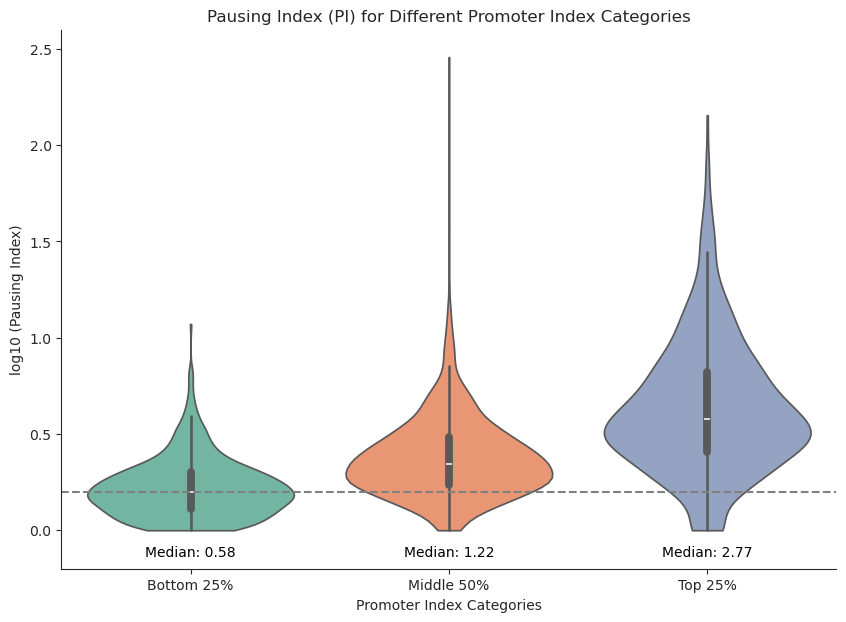

```python
import pandas as pd
import matplotlib.pyplot as plt
import seaborn as sns
import numpy as np
import matplotlib as mpl

# Set up plot style
mpl.rcParams['pdf.fonttype'] = 42
mpl.rcParams['ps.fonttype'] = 42
plt.rcParams['font.family'] = 'DejaVu Sans'
sns.set_style("ticks", {"font.family": "DejaVu Sans"})

# Load PROseq dataset
file_path = "/home/mayer/92_SPT4_SPT5/PROseq/analysis/PROseq_binding_merged.csv"
PROseq = pd.read_csv(file_path, sep=',')

# Merge SPT5 and PROseq data
merged_SPT5_PROseq = pd.merge(filtered_SPT5_RNAseq, PROseq, on='gene_ID')

# Clean data by removing rows with missing values
merged_SPT5_PROseq_clean = merged_SPT5_PROseq.dropna(subset=['2_4h_promoter_index', 'PROseq_34h_promoter_index']).copy()

# Apply log10 transformation to promoter indices for better visualization
merged_SPT5_PROseq_clean['log_2_4h_promoter_index'] = np.log10(merged_SPT5_PROseq_clean['2_4h_promoter_index'] + 1)
merged_SPT5_PROseq_clean['log_PROseq_34h_promoter_index'] = np.log10(merged_SPT5_PROseq_clean['PROseq_34h_promoter_index'] + 1)

# Exclude outliers (values greater than 10^3)
merged_SPT5_PROseq_clean = merged_SPT5_PROseq_clean[merged_SPT5_PROseq_clean['log_PROseq_34h_promoter_index'] <= 3]
merged_df = merged_SPT5_PROseq_clean

# Create the violin plot
plt.figure(figsize=(10, 7))
ax = plt.gca()
sns.violinplot(x="2_4h_promoter_index_category", y='log_PROseq_34h_promoter_index', data=merged_df, palette="Set2", ax=ax, cut=0)

# Set plot limits
plt.ylim(-0.2, 2.6)
ax.set_ylim(-0.2, 2.6)

# Display horizontal dashed line at the median of the bottom 25% category
cluster_1_median = np.median(
    merged_df[merged_df['2_4h_promoter_index_category'] == 1]['log_PROseq_34h_promoter_index'].dropna()
)
ax.axhline(y=cluster_1_median, color='grey', linestyle='--')

# Display medians for each category
categories_order = [1, 2, 3]
for i, category in enumerate(categories_order):
    category_data = merged_df[merged_df['2_4h_promoter_index_category'] == category]['PROseq_34h_promoter_index']
    median_pi = category_data.median()
    ax.text(
        x=i,
        y=-0.15,
        s=f'Median: {median_pi:.2f}',
        ha='center', va='bottom',
        color='black', fontsize=10
    )

# Final plot formatting
plt.title("Pausing Index (PI) for Different Promoter Index Categories")
plt.xlabel("Promoter Index Categories")
plt.ylabel("log10 (Pausing Index)")
plt.xticks(ticks=[0, 1, 2], labels=["Bottom 25%", "Middle 50%", "Top 25%"])

# Remove top and right spines (axes)
ax.spines['right'].set_visible(False)
ax.spines['top'].set_visible(False)

# Save and show plot
plt.savefig("/home/mayer/92_SPT4_SPT5/Manuscript/Figures/Figure_2/Figure_S_2_B_comparison_PROseq_34h.pdf")
plt.show()
```

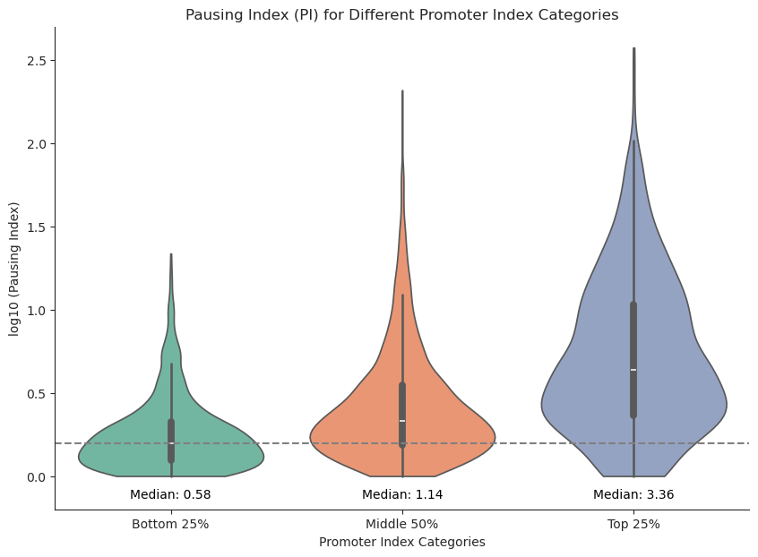

```python
import pandas as pd
import matplotlib.pyplot as plt
import seaborn as sns
import numpy as np
import matplotlib as mpl

mpl.rcParams['pdf.fonttype'] = 42
mpl.rcParams['ps.fonttype'] = 42
plt.rcParams['font.family'] = 'DejaVu Sans'
sns.set_style("ticks", {"font.family": "DejaVu Sans"})

# PROseq dataset
file_path = "/home/mayer/92_SPT4_SPT5/PROseq/analysis/PROseq_binding_merged.csv"
PROseq = pd.read_csv(file_path, sep=',')
merged_SPT5_PROseq = pd.merge(filtered_SPT5_RNAseq, PROseq, on='gene_ID')

merged_SPT5_PROseq_clean = merged_SPT5_PROseq.dropna(subset=['18_20h_promoter_index', 'PROseq_1820h_promoter_index']).copy()

# Perform log 10 transformation of index for visualization and exclude outlier
merged_SPT5_PROseq_clean['log_18_20h_promoter_index'] = np.log10(merged_SPT5_PROseq_clean['18_20h_promoter_index'] + 1)
merged_SPT5_PROseq_clean['log_PROseq_1820h_promoter_index'] = np.log10(merged_SPT5_PROseq_clean['PROseq_1820h_promoter_index'] + 1)
merged_SPT5_PROseq_clean = merged_SPT5_PROseq_clean[merged_SPT5_PROseq_clean['log_PROseq_1820h_promoter_index'] <= 3]
merged_df = merged_SPT5_PROseq_clean

# Generate plot
plt.figure(figsize=(10, 7))
ax = plt.gca()
sns.violinplot(x="18_20h_promoter_index_category", y='log_PROseq_1820h_promoter_index', data=merged_df, palette="Set2", ax=ax, cut=0)

# Determine median of Bottom 25%
cluster_1_median = np.median(
    merged_df[merged_df['18_20h_promoter_index_category'] == 1]['log_PROseq_1820h_promoter_index'].dropna()
)

# Display horizontal dashed line at median of Bottom 25%
ax.axhline(y=cluster_1_median, color='grey', linestyle='--')

# Show median for each category
categories_order = [1, 2, 3]
for i, category in enumerate(categories_order):
    category_data = merged_df[merged_df['18_20h_promoter_index_category'] == category]['PROseq_1820h_promoter_index']
    median_pi = category_data.median()
    ax.text(
        x=i,
        y=-0.15,
        s=f'Median: {median_pi:.2f}',
        ha='center', va='bottom',
        color='black', fontsize=10
    )

# Final plot formatting
plt.title("Pausing Index (PI) for Different Promoter Index Categories")
plt.xlabel("Promoter Index Categories")
plt.ylabel("log10 (Pausing Index)")

# Remove top and right spines (axes)
ax.spines['right'].set_visible(False)
ax.spines['top'].set_visible(False)

# Set limits and tick labels
plt.ylim(-0.2, 2.7)
plt.xticks(ticks=[0, 1, 2], labels=["Bottom 25%", "Middle 50%", "Top 25%"])

# Save and show plot
plt.savefig("/home/mayer/92_SPT4_SPT5/Manuscript/Figures/Figure_2/Figure_S_2_B_comparison_PROseq_1820h.pdf")
plt.show()
```

### Supplementary Figure 2 C: Gene lengths for consistent pausing categories

```python
import pandas as pd
import numpy as np

# Define the list of timepoints
timepoints = ["2_4h_promoter_index", "6_8h_promoter_index", "10_12h_promoter_index", "14_16h_promoter_index", "18_20h_promoter_index"]

# Function to categorize promoter index based on hard cutoff values
def categorize_promoter_index(row):
    PI_values = row[timepoints].dropna()

    if all(PI_values < 1):
        return "PI < 1"
    elif all((PI_values >= 1) & (PI_values <= 3)):
        return "1 <= PI <= 3"
    elif all(PI_values > 3):
        return "PI > 3"
    return None

# Apply the categorization function to the DataFrame
filtered_SPT5_NELF_RNAseq["PI_hard_cutoff"] = filtered_SPT5_NELF_RNAseq.apply(categorize_promoter_index, axis=1)
```

```
Excluding 3066 genes without a consistent pausing category
Using 4389 genes for plotting gene length distribution
   Using 2300 genes for category 1 <= PI <= 3
   Using 1104 genes for category PI > 3
   Using 985 genes for category PI < 1
```

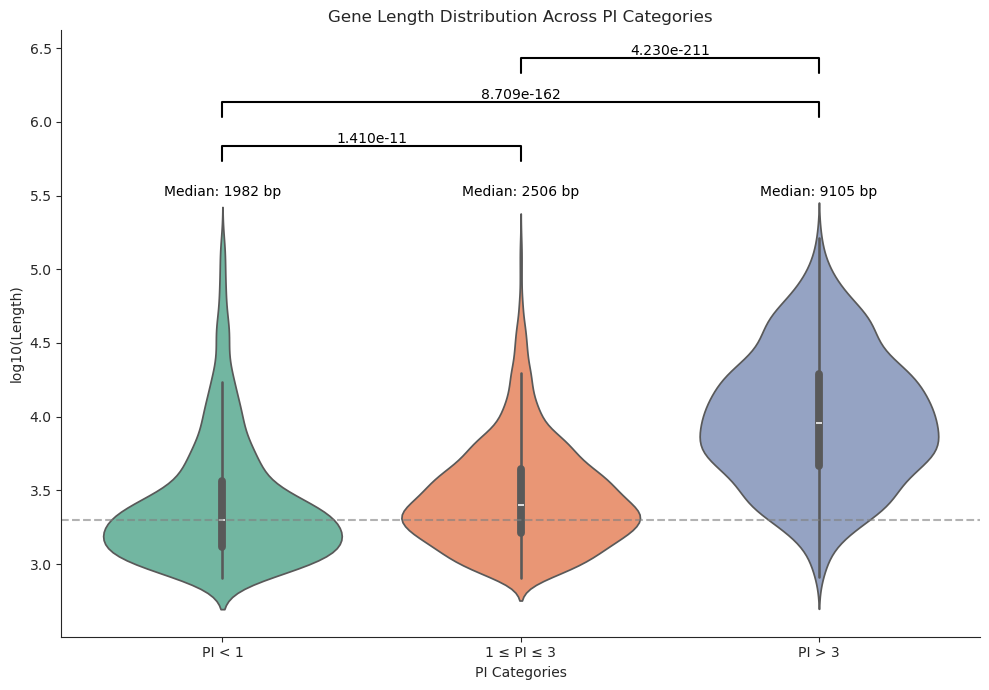

```python
import pandas as pd
import numpy as np
import seaborn as sns
import matplotlib.pyplot as plt
import itertools
from scipy.stats import mannwhitneyu

# Create a copy of the original DataFrame
filtered_SPT5_RNAseq_copy = filtered_SPT5_NELF_RNAseq.copy()

# Drop rows with missing pausing index categories
filtered_SPT5_RNAseq_copy = filtered_SPT5_RNAseq_copy.dropna(subset=['PI_hard_cutoff'])
filtered_SPT5_RNAseq_copy['length_category'] = filtered_SPT5_RNAseq_copy['PI_hard_cutoff']

# Only keep genes with consistent pausing index categories over time
filtered_SPT5_RNAseq_classified = filtered_SPT5_RNAseq_copy[filtered_SPT5_RNAseq_copy['length_category'] != 'Unclassified']
print(f"Excluding {len(filtered_SPT5_RNAseq) - len(filtered_SPT5_RNAseq_classified)} genes without a consistent pausing category")
print(f"Using {len(filtered_SPT5_RNAseq_classified)} genes for plotting gene length distribution")

category_counts = filtered_SPT5_RNAseq_classified['length_category'].value_counts()
for category, count in category_counts.items():
    print(f"   Using {count} genes for category {category}")

# Log-transform gene length for better visualization
filtered_SPT5_RNAseq_classified['log_length'] = np.log10(filtered_SPT5_RNAseq_classified['length'])

# Perform statistical comparison of gene length between categories
p_values = {}
categories = filtered_SPT5_RNAseq_classified['length_category'].unique()
category_pairs = list(itertools.combinations(categories, 2))

for pair in category_pairs:
    category1_data = filtered_SPT5_RNAseq_classified[filtered_SPT5_RNAseq_classified['length_category'] == pair[0]]['log_length']
    category2_data = filtered_SPT5_RNAseq_classified[filtered_SPT5_RNAseq_classified['length_category'] == pair[1]]['log_length']

    _, p_value = mannwhitneyu(category1_data, category2_data)
    p_values[pair] = p_value

# Generate violin plot
plt.figure(figsize=(10, 7))
ax = sns.violinplot(x='length_category', y='log_length', data=filtered_SPT5_RNAseq_classified, palette='Set2', hue='length_category')
new_labels = ['PI < 1', '1 ≤ PI ≤ 3', 'PI > 3']
ax.set_xticks(range(len(new_labels)))
ax.set_xticklabels(new_labels)

# Add significance lines based on statistical results
height_increment = 0.1
y_start = filtered_SPT5_RNAseq_classified['log_length'].max() + 0.5

for i, (pair, p_value) in enumerate(p_values.items()):
    if p_value < 0.001:
        significance = '***'
    elif p_value < 0.01:
        significance = '**'
    elif p_value < 0.05:
        significance = '*'
    else:
        significance = 'ns'

    x1_pos = categories.tolist().index(pair[0])
    x2_pos = categories.tolist().index(pair[1])

    # Add significance stars
    ax.plot([x1_pos, x1_pos, x2_pos, x2_pos], [y_start, y_start + height_increment, y_start + height_increment, y_start], lw=1.5, color='k')
    ax.text((x1_pos + x2_pos) * 0.5, y_start + height_increment, f'{p_value:.3e}', ha='center', va='bottom', color='k')
    y_start += height_increment + 0.2

# Draw horizontal line for the median of the bottom 25%
for i, category in enumerate(categories):
    category_data = filtered_SPT5_RNAseq_classified[filtered_SPT5_RNAseq_classified['length_category'] == category]['log_length']
    median_length = category_data.median()
    median_length_unlog = 10 ** median_length

    if i < 1:
        ax.axhline(y=median_length, color='grey', linestyle='--', alpha=0.6)
    ax.text(i, 5.5, f'Median: {median_length_unlog:.0f} bp', ha='center', color='black', fontsize=10)

# Customize plot appearance
plt.title("Gene Length Distribution Across PI Categories")
plt.xlabel("PI Categories")
plt.ylabel("log10(Length)")
ax.spines['right'].set_visible(False)
ax.spines['top'].set_visible(False)
plt.tight_layout()

# Save the plot
plt.savefig("/home/mayer/92_SPT4_SPT5/Manuscript/Figures/Figure_2/Figure_2_G_gene_length_violin_PI_cats.pdf")
plt.show()
```

### Supplementary Figure 2 D: NELF binding stacked bar plots

```python
import pandas as pd
from tqdm import tqdm
import numpy as np

desired_chromosomes = ["chrX", "chrY", "chr2L", "chr2R", "chr3L", "chr3R", "chr4"]

# Load peaks and only use genes from desired chromosomes
def read_peaks(path, desired_chromosomes):
    peaks_df = pd.read_csv(path, sep='\t', header=None, usecols=[0, 1, 2, 10], names=['chrom', 'start', 'end', 'score'])
    all_peaks = len(peaks_df)
    print(f"Calculated {all_peaks} peaks for file {path}")

    peaks_df = peaks_df[peaks_df['chrom'].isin(desired_chromosomes)]
    print(f"Using {len(peaks_df)} from desired chromosomes, ignoring {all_peaks - len(peaks_df)}")
    return peaks_df

# Check if TSS of gene is inside NELF peak and return peak score
def check_peak(row, peaks_df):
    peaks_subset = peaks_df[peaks_df['chrom'] == row['chrom']]
    for _, peak in peaks_subset.iterrows():
        if peak['start'] <= row['TSS'] <= peak['end']:
            return peak['score']
    return np.nan

# Determine TSS position
def get_tss(row):
    return row['start'] if row['strand'] == '+' else row['end']

# Check peaks with tqdm to determine duration of checking
def apply_check_peak(NELF_df, peaks_df, column_name_bound, column_name_score):
    tqdm.pandas()
    NELF_df['TSS'] = NELF_df.apply(get_tss, axis=1)
    NELF_df[column_name_score] = NELF_df.progress_apply(check_peak, axis=1, peaks_df=peaks_df)
    NELF_df[column_name_bound] = NELF_df[column_name_score].notna()
    return NELF_df

# Determine peaks for each timepoint
def run_peak_analysis(antibody):
    NELF_df = filtered_SPT5_RNAseq.copy()
    directory = '/home/mayer/92_SPT4_SPT5/Depletion_CUTnTag/analysis/IDR/Dmel/'

    for timepoint in ["3-4h_3hdepletion", "10-12h_2hdepletion", "18-20h_2hdepletion"]:
        peaks_df = read_peaks(
            f"{directory}SPT5longLEXY_{timepoint}.Dark.{antibody}_IDR_peaks_expanded_RPKM_filtered_extended.bed",
            desired_chromosomes
        )
        column_name_bound = f"{timepoint}_peak"
        column_name_score = f"{timepoint}_peak_score"
        NELF_df = apply_check_peak(NELF_df, peaks_df, column_name_bound, column_name_score)

    path = f'/home/mayer/92_SPT4_SPT5/Manuscript/Figures/Figure_2/{antibody}_df_all_timepoints.csv'
    NELF_df.to_csv(path, index=False)

run_peak_analysis('NELF')
```

```
Calculated 5170 peaks for file /home/mayer/92_SPT4_SPT5/Depletion_CUTnTag/analysis/IDR/Dmel/SPT5longLEXY_3-4h_3hdepletion.Dark.NELF_IDR_peaks_expanded_RPKM_filtered_extended.bed
Using 5164 from desired chromosomes, ignoring 6
```

```
Calculated 5419 peaks for file /home/mayer/92_SPT4_SPT5/Depletion_CUTnTag/analysis/IDR/Dmel/SPT5longLEXY_10-12h_2hdepletion.Dark.NELF_IDR_peaks_expanded_RPKM_filtered_extended.bed
Using 5412 from desired chromosomes, ignoring 7
```

```
Calculated 4830 peaks for file /home/mayer/92_SPT4_SPT5/Depletion_CUTnTag/analysis/IDR/Dmel/SPT5longLEXY_18-20h_2hdepletion.Dark.NELF_IDR_peaks_expanded_RPKM_filtered_extended.bed
Using 4821 from desired chromosomes, ignoring 9
```

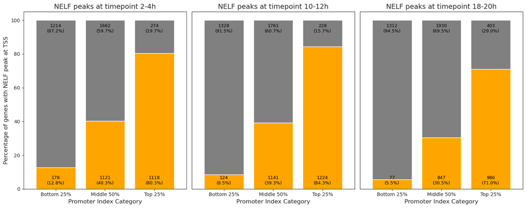

```python
import pandas as pd
import matplotlib.pyplot as plt

# Path to NELF df with peak information
path = '/home/mayer/92_SPT4_SPT5/Manuscript/Figures/Figure_2/NELF_df_all_timepoints.csv'
NELF_df = pd.read_csv(path)

colors = ['#FFA162', '#919191']

fig, axes = plt.subplots(1, 3, figsize=(15, 6), sharey=True)

categories = ['Bottom 25%', 'Middle 50%', 'Top 25%']
timepoints = ['2-4h', '10-12h', '18-20h']
peak_columns = ['3-4h_3hdepletion_peak', '10-12h_2hdepletion_peak', '18-20h_2hdepletion_peak']
promoter_columns = ['2_4h_promoter_index_category', '10_12h_promoter_index_category', '18_20h_promoter_index_category']

for i, (timepoint, peak_col, promoter_col, ax) in enumerate(zip(timepoints, peak_columns, promoter_columns, axes)):
    filtered_df_selected = NELF_df.dropna(subset=[promoter_col, peak_col])
    peak_counts = filtered_df_selected.groupby([promoter_col, peak_col]).size().unstack(fill_value=0)
    peak_counts_percentage = peak_counts.divide(peak_counts.sum(axis=1), axis=0).fillna(0) * 100

    peak_counts_percentage = peak_counts_percentage.reindex(columns=[True, False])  # Change order of plotting
    peak_counts_percentage.plot(kind='bar', stacked=True, ax=ax,
                                color=['orange', 'grey'], width=0.8, align="center")


    # Add number of genes/ percentage in each category
    for j, (index, row) in enumerate(peak_counts.iterrows()):
        with_peak = row[False]
        percentage_peak = peak_counts_percentage.loc[index].iloc[1]
        without_peak = row[True]
        percentage_no_peak = peak_counts_percentage.loc[index].iloc[0]
        ax.text(j, 95, f'{int(with_peak)}\n({percentage_peak:.1f}%)', ha='center', va='center', fontsize=9, color='black')
        ax.text(j, 5, f'{int(without_peak)}\n({percentage_no_peak:.1f}%)', ha='center', va='center', fontsize=9, color='black')


    ax.set_title(f'NELF peaks at timepoint {timepoint}', fontsize=14)
    ax.set_xlabel('Promoter Index Category', fontsize=12)
    ax.set_xticklabels(categories, rotation=0)

    ax.legend_.remove()
    if i > 0:
        ax.set_yticklabels([])
        ax.tick_params(axis='y', length=0)
        ax.set_ylabel('')


axes[0].set_ylabel('Percentage of genes with NELF peak at TSS', fontsize=12)
axes[0].set_yticks([0, 20, 40, 60, 80, 100])
axes[0].set_yticklabels(['0', '20', '40', '60', '80', '100'])
plt.tight_layout()
plt.savefig('/home/mayer/92_SPT4_SPT5/Manuscript/Figures/Figure_2/Figure_S_2_C_NELF_peaks_in_pausing_category.pdf')
plt.show()
```

### Supplementary Figure 2 E: Motif bootsstrapping analysis

```python
import pandas as pd
import seaborn as sns
import matplotlib.pyplot as plt
import numpy as np
from scipy.stats import mannwhitneyu
import random
from itertools import combinations
import warnings
from pybiomart import Dataset

# Set font parameters for plots
import matplotlib as mpl
mpl.rcParams['pdf.fonttype'] = 42
mpl.rcParams['ps.fonttype'] = 42
plt.rcParams['font.family'] = 'Arial'
sns.set_style("ticks", {"font.family": "Arial"})

warnings.filterwarnings("ignore")

# Function to load relevant genes from a BED file
def load_relevant_genes_from_bed(bed_file):
    bed_data = pd.read_csv(bed_file, sep='\t', header=None)
    relevant_genes = set(bed_data[3].unique())
    return relevant_genes

# Load the Excel file
file_path = "/home/mayer/92_SPT4_SPT5/Motif_analysis/data/CORE_EPDnew_Aug2023.xlsx"
df = pd.read_excel(file_path, sheet_name="fly")
df['genname'] = df['name'].str.split('_').str[0]

# Query Ensembl for gene IDs
dataset = Dataset(name='dmelanogaster_gene_ensembl', host='http://www.ensembl.org')
results = dataset.query(attributes=['external_gene_name', 'flybase_gene_id'])
results.columns = ['genname', 'GeneID']
core_df_with_ids = df.merge(results, on='genname', how='left')
core_df_with_ids.to_csv("/home/mayer/92_SPT4_SPT5/Motif_analysis/data/core_df_with_ids.csv", sep="\t", index=False)

# Define relevant motif columns
motif_columns = [
    'GAGA', 'BREu', 'TATA', 'BREd', 'XCPE1', 'XCPE2',
    'Motif1', 'dTCT', 'hTCT', 'BBCABW', 'hInr', 'dInr',
    'MTE', 'bridge', 'DPE', 'PB'
]

# Function to calculate motif combination counts
def calculate_motif_combination_counts(core_df_with_ids, selected_genes, motif_columns):
    filtered_core_df = core_df_with_ids[core_df_with_ids['genname'].isin(selected_genes) | core_df_with_ids['GeneID'].isin(selected_genes)]
    total_genes = len(filtered_core_df)
    motif_combination_counts = {}

    all_combinations = [comb for r in range(1, 2) for comb in combinations(motif_columns, r)]

    for comb in all_combinations:
        comb_key = ' & '.join(comb)
        filtered_core_df['combination_match'] = filtered_core_df[list(comb)].apply(
            lambda row: all(val != 'no' for val in row), axis=1
        )
        matching_genes = filtered_core_df.loc[filtered_core_df['combination_match'], 'GeneID']
        count = len(matching_genes)
        percentage = (count / total_genes) * 100 if total_genes > 0 else 0
        motif_combination_counts[comb_key] = percentage

    return motif_combination_counts

# Function for bootstrap analysis of motif combinations
def bootstrap_motif_analysis(core_df_with_ids, relevant_genes, motif_columns, n_iterations):
    print(f"Parsing {n_iterations} iterations...")
    results = {}
    all_combinations = [' & '.join(comb) for r in range(1, 2) for comb in combinations(motif_columns, r)]
    for comb in all_combinations:
        results[comb] = []

    for _ in range(n_iterations):
        selected_genes = random.sample(list(relevant_genes), int(len(relevant_genes) * 0.1))
        motif_combination_counts = calculate_motif_combination_counts(core_df_with_ids, selected_genes, motif_columns)
        for comb, percentage in motif_combination_counts.items():
            results[comb].append(percentage)

    return results

# Main function to analyze motifs using bootstrap method
def analyze_motifs_with_bootstrap(core_df_with_ids, motif_columns, bed_files, output_dir, n_iterations):
    combined_results = {}
    categories = ['1', '2', '3']
    all_combinations = [' & '.join(comb) for r in range(1, 2) for comb in combinations(motif_columns, r)]
    for comb in all_combinations:
        combined_results[comb] = {category: [] for category in categories}

    for index, bed_file in enumerate(bed_files):
        print(f"Parsing BED file {bed_file}...")
        relevant_genes = load_relevant_genes_from_bed(bed_file)
        category = categories[index]
        bootstrap_results = bootstrap_motif_analysis(core_df_with_ids, relevant_genes, motif_columns, n_iterations)
        for comb, percentages in bootstrap_results.items():
            combined_results[comb][category].extend(percentages)

    print("Producing summary...")
    rows = []
    for comb, category_data in combined_results.items():
        row = {'Motif Combination': comb}
        for category, percentages in category_data.items():
            row[f'Category {category} Percentages'] = percentages
        rows.append(row)

    return pd.DataFrame(rows)

# List of interesting motifs
interesting_motifs = ['TATA', 'GAGA', 'BREu', 'PB', 'bridge', 'DPE', 'dInr']

output_dir = "/home/mayer/92_SPT4_SPT5/Manuscript/Figures/Figure_2/categories_per_timepoint/consistent_categories/"
bed_files = [
    output_dir + 'PI<1_genes.bed',
    output_dir + '1<PI<3_genes.bed',
    output_dir + 'PI>3_genes.bed'
]

# Perform bootstrap analysis and save results
combined_results_df = analyze_motifs_with_bootstrap(core_df_with_ids, interesting_motifs, bed_files, output_dir, n_iterations=10000)

plot_dir = "/home/mayer/92_SPT4_SPT5/Manuscript/Figures/Figure_2/motif_analysis"
combined_results_df.to_csv(f'{plot_dir}/motif_analysis_combined_results_10k_PI_cutoffs.tsv', sep='\t', index=False)

print("Finished")

# Function to summarize combination data for plotting
def create_combination_summary(combined_results_df):
    summary_data = {}
    for _, row in combined_results_df.iterrows():
        motif_comb = row['Motif Combination']
        categories_percentages = {
            'Category 1': row['Category 1 Percentages'],
            'Category 2': row['Category 2 Percentages'],
            'Category 3': row['Category 3 Percentages']
        }
        motifs = motif_comb.split(' & ')
        motif_count = len(motifs)
        for i in range(motif_count):
            for motif in motifs:
                motif_label = f'{motif} + {motif_count-1}X'
                if motif_label not in summary_data:
                    summary_data[motif] = {
                        'Motif': motif,
                        'Combination_summary': motif,
                        'Category 1 Percentages': [],
                        'Category 2 Percentages': [],
                        'Category 3 Percentages': []
                    }
                summary_data[motif]['Category 1 Percentages'].append(categories_percentages.get('Category 1', np.nan))
                summary_data[motif]['Category 2 Percentages'].append(categories_percentages.get('Category 2', np.nan))
                summary_data[motif]['Category 3 Percentages'].append(categories_percentages.get('Category 3', np.nan))

    return pd.DataFrame(list(summary_data.values()))

# Create summary DataFrame
summary_df = create_combination_summary(combined_results_df)

# Prepare data for plotting
plot_data = []
for _, row in summary_df.iterrows():
    motif_combination = row['Combination_summary']
    categories = ['Category 1 Percentages', 'Category 2 Percentages', 'Category 3 Percentages']
    for category in categories:
        percentages = row[category]
        for percentage in percentages:
            plot_data.append({
                'Motif Combination': motif_combination,
                'Category': category,
                'Percentage': percentage
            })

plot_df = pd.DataFrame(plot_data)

# Plotting
plt.figure(figsize=(12, 6))
sns.set(style="whitegrid")
expanded_df = plot_df.explode('Percentage').reset_index(drop=True)

ax = sns.boxplot(x='Motif Combination', y='Percentage', hue='Category',
                 data=expanded_df, palette="Set2", flierprops={'marker': 'o', 'markersize': 0}, dodge=True)

# Perform Mann-Whitney U tests between categories and annotate the plot
for motif in plot_df['Motif Combination'].unique():
    motif_data = plot_df[plot_df['Motif Combination'] == motif]
    categories = motif_data['Category'].unique()
    p_values = {}
    for cat1, cat2 in itertools.combinations(categories, 2):
        data_cat1 = motif_data[motif_data['Category'] == cat1]['Percentage'].dropna().explode().astype(float)
        data_cat2 = motif_data[motif_data['Category'] == cat2]['Percentage'].dropna().explode().astype(float)
        stat, p_value = mannwhitneyu(data_cat1, data_cat2)
        p_values[(cat1, cat2)] = p_value

# Display plot
plt.xticks(rotation=45, ha='right')
plt.tight_layout()
plt.show()
```

[output not shown]